# Análisis Exploratorio de Datos (EDA)

# 8 Relación entre dependencia y comportamiento de voto

Las secciones anteriores miraron la dependencia y los votos por separado o promediadas. Para evaluar la relación bivariada al nivel observación (país-año), graficamos un diagrama de dispersión con todos los puntos y le superponemos una recta de regresión lineal. Replicamos el gráfico filtrando el outlier para apreciar la relación en el rango donde se concentran los datos.

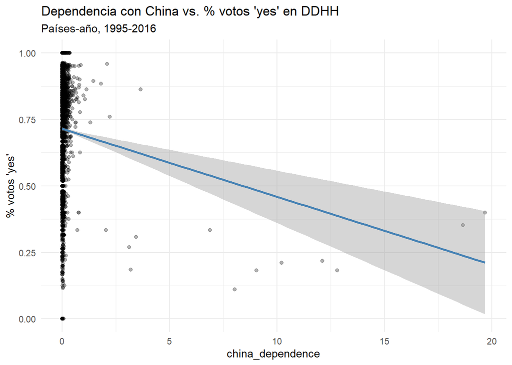

Dispersión de china_dependence vs. pct_yes (todos los datos).

```r
# Dispersión con todos los datos. alpha=0.3 para que se distinga la
# densidad de los puntos donde se acumulan; method='lm' para una
# regresión lineal simple (la materia no cubre métodos no-paramétricos).
dataset |>
  filter(!is.na(china_dependence), !is.na(pct_yes)) |>
  ggplot(aes(x = china_dependence, y = pct_yes)) +
  geom_point(alpha = 0.3) +
  geom_smooth(method = "lm", color = "steelblue") +
  labs(
    title = "Dependencia con China vs. % votos 'yes' en DDHH",
    subtitle = "Países-año, 1995-2016",
    x = "china_dependence",
    y = "% votos 'yes'") +
  theme_minimal()
```

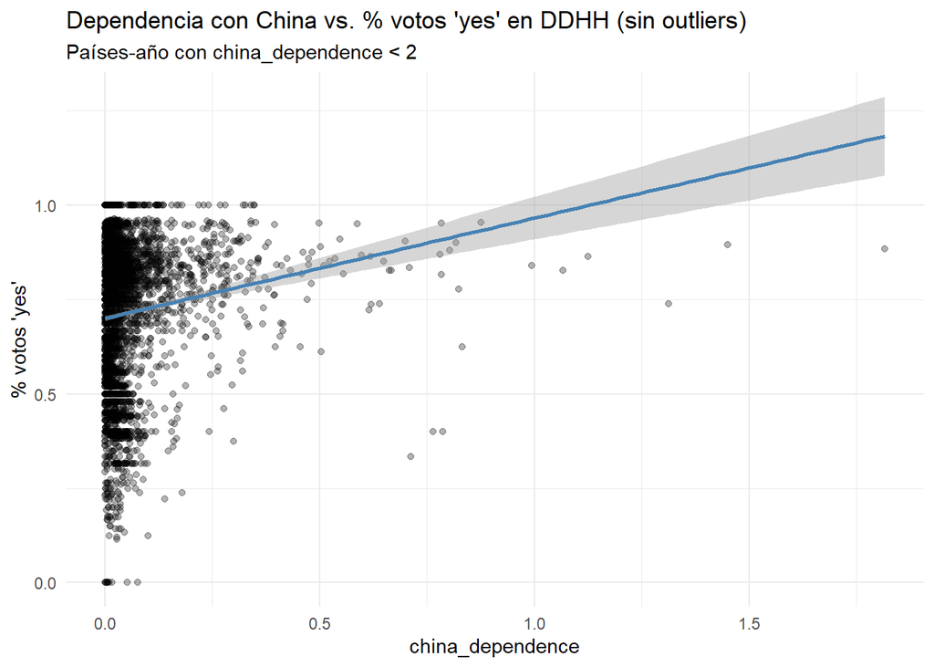

Dispersión de china_dependence vs. pct_yes excluyendo china_dependence >= 2.

```r
# Mismo gráfico, filtrando el outlier para que la nube de puntos
# del grueso de los países sea visible.
dataset |>
  filter(!is.na(china_dependence), !is.na(pct_yes), china_dependence < 2) |>
  ggplot(aes(x = china_dependence, y = pct_yes)) +
  geom_point(alpha = 0.3) +
  geom_smooth(method = "lm", color = "steelblue") +
  labs(
    title = "Dependencia con China vs. % votos 'yes' en DDHH (sin outliers)",
    subtitle = "Países-año con china_dependence < 2",
    x = "china_dependence",
    y = "% votos 'yes'") +
  theme_minimal()
```

En el scatter con todos los datos, la línea de regresión tiene pendiente negativa. Esto está dominado por el outlier de Marshall Islands, que combina alta dependencia comercial con bajo porcentaje de votos “yes” en DDHH (vota frecuentemente alineado con Estados Unidos). El outlier “tira” la línea hacia abajo. Al filtrar los valores extremos, la pendiente se invierte y la relación que predomina en el grueso de los países queda visible.

La nube de puntos del scatter sin outliers muestra la **alta variabilidad de `pct_yes` para cualquier nivel de dependencia**: para un mismo valor de `china_dependence`, el porcentaje de votos “yes” puede ir de 0 a 1. La recta de regresión lineal tiene **pendiente positiva**, lo cual es coherente con la diferencia de medianas observada en el boxplot: a mayor dependencia, en promedio un poco más de votos “yes”. Sin embargo, la dispersión vertical en torno a la línea es mucho mayor que el efecto de la pendiente, lo cual sugiere que `china_dependence` por sí sola explica una fracción pequeña de la variabilidad del comportamiento de voto y que cualquier modelo predictivo serio necesitaría incorporar otras dimensiones (ideología, alineación, región, etc.).